# Neural Network Lab

### Sam Freund

In this lab you will be experimenting with ANNs. Let's start by importing a few things.

```python
%matplotlib inline
import matplotlib.pyplot as plt
import numpy as np
from sklearn.metrics import accuracy_score
from sklearn.metrics import ConfusionMatrixDisplay
from sklearn.metrics import confusion_matrix
from sklearn.datasets import make_blobs
from sklearn.model_selection import train_test_split

import tensorflow.keras as keras
import tensorflow as tf
from tensorflow.keras.models import Sequential
from tensorflow.keras.layers import Dense, Dropout, Flatten, Conv2D, MaxPooling2D
from tensorflow.keras import backend as K
from tensorflow.keras import layers
from tensorflow.keras.preprocessing.image import ImageDataGenerator
```

We first generate some dummy data from random samples in a 2D space from 4 clusters.

```python
n_samples = 1000
variance = 0.01

# 4 clusters in a 2D space
centers = np.array([[0, 0],
                    [0, 1],
                    [1, 0],
                    [1, 1]])

X, y = make_blobs(n_samples,
                  centers=centers,
                  cluster_std = np.sqrt(variance),
                  shuffle=True)
```

Let's use matplot lib to plot the clusters of the `X` values coloring the points according to their labels (`y`)

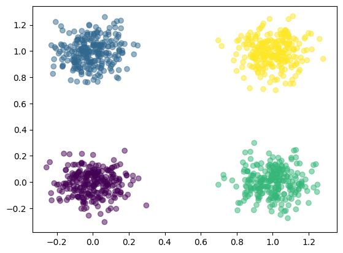

```python
plt.scatter(X[:,0],X[:,1], c=y, alpha=0.5)
plt.show()
```

## Exercise 1

Time to classify this data. Because of how separable this data is, we can just use simple conditional statements and we should get to 100% accuracy.

```python
def my_classifier(X):
    ''' This function takes a NumPy vector with 2 variables and returns a classification value (0-3)
    '''
    if (X[0] < .5 and X[1] < .5):
        return 0
    elif (X[0] < .5 and X[1] >= .5):
        return 1
    elif (X[0] >= .5 and X[1] < .5):
        return 2
    elif (X[0] >= .5 and X[1] >= .5):
        return 3
    else:
        return -1

def run_my_classifier(X, y):
    ''' This function takes a vector of pairs of points, classifies each pair using my_classifier, and
    then compares the predicted y value with the actual y values in the y variable.  It should return the
    accuracy value for the two vectors.
    '''
    y_out = np.apply_along_axis(my_classifier, 1, X)
    correct = (y == y_out)
    accuracy = correct.sum() / correct.size
    return accuracy
```

```python
run_my_classifier(X,y)
```

```
1.0
```

In the cell below, generate a new data set (i.e., X2, y2) that has a higher variance than the first data set (at least 0.1). Run your classifier on the new data and display the accuracy below.

```python
n_samples = 1000
variance = 0.17

# 4 clusters in a 2D space
centers = np.array([[0, 0],
                    [0, 1],
                    [1, 0],
                    [1, 1]])

X_2, y_2 = make_blobs(n_samples,
                  centers=centers,
                  cluster_std = np.sqrt(variance),
                  shuffle=True)
```

```python
run_my_classifier(X_2, y_2)
```

```
0.794
```

## Multi-Layer Perceptron

We now define a function to create and train a Multi-layer Perceptron (MLP) classifier. Calling this function will train the model and generate some print statements that show the confusion matrix output.

```python
def run_mlp(X_train, y_train, X_test, y_test, out_class=4, hidden=16, epochs=100):
    model = Sequential()
    model.add(Flatten())
    model.add(Dense(hidden, activation='relu'))
    model.add(Dense(out_class, activation='softmax'))
    model.compile(loss="sparse_categorical_crossentropy",
              optimizer=keras.optimizers.SGD(),
              metrics=['accuracy'])
    history = model.fit(x=X_train,y=y_train,epochs=epochs,verbose=2)
    model.summary()
    predicted_probabilities = model.predict(X_train)
    predicted_classes = np.argmax(predicted_probabilities, axis=1)
    acc = 100. * accuracy_score(y_train, predicted_classes)
    print("Accuracy on train set: {:.2f}%".format(acc))
    predicted_probabilities = model.predict(X_test)
    predicted_classes = np.argmax(predicted_probabilities, axis=1)
    acc = 100. * accuracy_score(y_test, predicted_classes)
    print("Accuracy on test set: {:.2f}%".format(acc))
    print(confusion_matrix(y_test, predicted_classes))
```

Next, lets see how well the original (low variance) data can be clustered with the MLP. First, we need to make sure we split the data into training and testing sets to identify overfitting.

```python
X_train, X_test, y_train, y_test = train_test_split(X, y, random_state=10)
run_mlp(X_train, y_train, X_test, y_test, 4, 16, 5)
```

```
24/24 - 1s - loss: 1.2365 - accuracy: 0.4053 - 612ms/epoch - 26ms/step
24/24 - 0s - loss: 1.1930 - accuracy: 0.4987 - 87ms/epoch - 4ms/step
```

[output not shown]

```
24/24 - 0s - loss: 1.1512 - accuracy: 0.5320 - 95ms/epoch - 4ms/step
24/24 - 0s - loss: 1.1112 - accuracy: 0.5653 - 95ms/epoch - 4ms/step
24/24 - 0s - loss: 1.0742 - accuracy: 0.6013 - 96ms/epoch - 4ms/step
Model: "sequential_24"
_________________________________________________________________
 Layer (type)                Output Shape              Param #
=================================================================
 flatten_24 (Flatten)        (None, 2)                 0

 dense_48 (Dense)            (None, 16)                48

 dense_49 (Dense)            (None, 4)                 68

=================================================================
Total params: 116 (464.00 Byte)
Trainable params: 116 (464.00 Byte)
Non-trainable params: 0 (0.00 Byte)
_________________________________________________________________
Accuracy on train set: 61.60%
Accuracy on test set: 63.20%
[[27 23  0  7]
 [ 0 65  0  0]
 [ 0  0  0 62]
 [ 0  0  0 66]]
```

## Exercise 2:

Re-run the experiment at least 5 more times with different numbers of epochs in the next cell and plot the results to show the overall accuracy (both training and testing) vs. the number of epochs. You may record these values in a list below by hand.

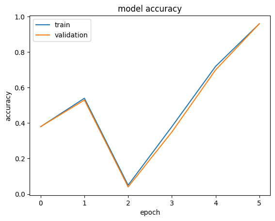

```python
# for i in range(1, 7):
#     X_train, X_test, y_train, y_test = train_test_split(X, y, random_state=10)
#     run_mlp(X_train, y_train, X_test, y_test, 4, 16, i)

accuracy_train = [ 0.38, 0.54, 0.05, 0.38, 0.72, 0.96 ]
accuracy_test = [ 0.38, 0.53, 0.04, 0.35, 0.7, 0.96 ]

plt.plot(accuracy_train)
plt.plot(accuracy_test)
plt.title('model accuracy')
plt.ylabel('accuracy')
plt.xlabel('epoch')
plt.legend(['train', 'validation'], loc='upper left')
plt.show()
```

## Exercise 3:

Run at least 5 experiments in the next cell by trying different numbers of neurons in the hidden layer. I would discourage changing the number of epochs so that you can truly see the effect of changing the number of hidden layers. Identify the smallest number of hidden neurons you could use and still achieve high accuracy. Complete the table in the lab report to show your experimental results. Make sure your table adequately documents your experimental variables (hyperparameters, dataset) to enable reproducability. Answer the reflection questions in the lab document.

```python
for i in range(1, 7):
    X_train, X_test, y_train, y_test = train_test_split(X, y, random_state=10)
    run_mlp(X_train, y_train, X_test, y_test, 4, 4*i, 5)
```

```
24/24 - 0s - loss: 1.6089 - accuracy: 0.0253 - 456ms/epoch - 19ms/step
24/24 - 0s - loss: 1.5429 - accuracy: 0.1027 - 85ms/epoch - 4ms/step
```

[output not shown]

```
24/24 - 0s - loss: 1.5075 - accuracy: 0.0813 - 93ms/epoch - 4ms/step
24/24 - 0s - loss: 1.4830 - accuracy: 0.0667 - 95ms/epoch - 4ms/step
24/24 - 0s - loss: 1.4631 - accuracy: 0.0520 - 94ms/epoch - 4ms/step
Model: "sequential_31"
_________________________________________________________________
 Layer (type)                Output Shape              Param #
=================================================================
 flatten_31 (Flatten)        (None, 2)                 0

 dense_62 (Dense)            (None, 4)                 12

 dense_63 (Dense)            (None, 4)                 20

=================================================================
Total params: 32 (128.00 Byte)
Trainable params: 32 (128.00 Byte)
Non-trainable params: 0 (0.00 Byte)
_________________________________________________________________
Accuracy on train set: 6.27%
Accuracy on test set: 4.00%
[[ 3  0  0 54]
 [ 0  0 65  0]
 [ 0 55  7  0]
 [ 0  0 66  0]]
24/24 - 0s - loss: 1.4225 - accuracy: 0.0800 - 485ms/epoch - 20ms/step
24/24 - 0s - loss: 1.3693 - accuracy: 0.1853 - 73ms/epoch - 3ms/step
```

[output not shown]

```
24/24 - 0s - loss: 1.3238 - accuracy: 0.2547 - 96ms/epoch - 4ms/step
24/24 - 0s - loss: 1.2840 - accuracy: 0.2707 - 101ms/epoch - 4ms/step
24/24 - 0s - loss: 1.2476 - accuracy: 0.4693 - 103ms/epoch - 4ms/step
Model: "sequential_32"
_________________________________________________________________
 Layer (type)                Output Shape              Param #
=================================================================
 flatten_32 (Flatten)        (None, 2)                 0

 dense_64 (Dense)            (None, 8)                 24

 dense_65 (Dense)            (None, 4)                 36

=================================================================
Total params: 60 (240.00 Byte)
Trainable params: 60 (240.00 Byte)
Non-trainable params: 0 (0.00 Byte)
_________________________________________________________________
Accuracy on train set: 50.00%
Accuracy on test set: 51.60%
[[ 1  0 56  0]
 [65  0  0  0]
 [ 0  0 62  0]
 [ 0  0  0 66]]
24/24 - 1s - loss: 1.3585 - accuracy: 0.3240 - 533ms/epoch - 22ms/step
24/24 - 0s - loss: 1.3116 - accuracy: 0.2600 - 79ms/epoch - 3ms/step
```

[output not shown]

```
24/24 - 0s - loss: 1.2690 - accuracy: 0.2933 - 94ms/epoch - 4ms/step
24/24 - 0s - loss: 1.2305 - accuracy: 0.5120 - 95ms/epoch - 4ms/step
24/24 - 0s - loss: 1.1952 - accuracy: 0.6080 - 95ms/epoch - 4ms/step
Model: "sequential_33"
_________________________________________________________________
 Layer (type)                Output Shape              Param #
=================================================================
 flatten_33 (Flatten)        (None, 2)                 0

 dense_66 (Dense)            (None, 12)                36

 dense_67 (Dense)            (None, 4)                 52

=================================================================
Total params: 88 (352.00 Byte)
Trainable params: 88 (352.00 Byte)
Non-trainable params: 0 (0.00 Byte)
_________________________________________________________________
Accuracy on train set: 65.20%
Accuracy on test set: 65.60%
[[32  3 22  0]
 [ 0 65  0  0]
 [ 0  0  1 61]
 [ 0  0  0 66]]
24/24 - 0s - loss: 1.3494 - accuracy: 0.4107 - 478ms/epoch - 20ms/step
24/24 - 0s - loss: 1.2745 - accuracy: 0.5880 - 73ms/epoch - 3ms/step
```

[output not shown]

```
24/24 - 0s - loss: 1.2084 - accuracy: 0.6560 - 94ms/epoch - 4ms/step
24/24 - 0s - loss: 1.1505 - accuracy: 0.6973 - 102ms/epoch - 4ms/step
24/24 - 0s - loss: 1.0969 - accuracy: 0.8120 - 103ms/epoch - 4ms/step
Model: "sequential_34"
_________________________________________________________________
 Layer (type)                Output Shape              Param #
=================================================================
 flatten_34 (Flatten)        (None, 2)                 0

 dense_68 (Dense)            (None, 16)                48

 dense_69 (Dense)            (None, 4)                 68

=================================================================
Total params: 116 (464.00 Byte)
Trainable params: 116 (464.00 Byte)
Non-trainable params: 0 (0.00 Byte)
_________________________________________________________________
Accuracy on train set: 91.60%
Accuracy on test set: 91.60%
[[50  2  3  2]
 [ 0 51  0 14]
 [ 0  0 62  0]
 [ 0  0  0 66]]
24/24 - 1s - loss: 1.3159 - accuracy: 0.2560 - 553ms/epoch - 23ms/step
24/24 - 0s - loss: 1.2802 - accuracy: 0.2960 - 78ms/epoch - 3ms/step
```

[output not shown]

```
24/24 - 0s - loss: 1.2456 - accuracy: 0.4507 - 95ms/epoch - 4ms/step
24/24 - 0s - loss: 1.2115 - accuracy: 0.5880 - 95ms/epoch - 4ms/step
24/24 - 0s - loss: 1.1782 - accuracy: 0.6667 - 95ms/epoch - 4ms/step
Model: "sequential_35"
_________________________________________________________________
 Layer (type)                Output Shape              Param #
=================================================================
 flatten_35 (Flatten)        (None, 2)                 0

 dense_70 (Dense)            (None, 20)                60

 dense_71 (Dense)            (None, 4)                 84

=================================================================
Total params: 144 (576.00 Byte)
Trainable params: 144 (576.00 Byte)
Non-trainable params: 0 (0.00 Byte)
_________________________________________________________________
Accuracy on train set: 73.33%
Accuracy on test set: 72.00%
[[24  1 26  6]
 [ 0 29  0 36]
 [ 0  0 62  0]
 [ 0  0  1 65]]
24/24 - 1s - loss: 1.2648 - accuracy: 0.4987 - 542ms/epoch - 23ms/step
24/24 - 0s - loss: 1.2209 - accuracy: 0.4573 - 79ms/epoch - 3ms/step
```

[output not shown]

```
24/24 - 0s - loss: 1.1804 - accuracy: 0.5853 - 96ms/epoch - 4ms/step
24/24 - 0s - loss: 1.1433 - accuracy: 0.6400 - 95ms/epoch - 4ms/step
24/24 - 0s - loss: 1.1088 - accuracy: 0.6893 - 98ms/epoch - 4ms/step
Model: "sequential_36"
_________________________________________________________________
 Layer (type)                Output Shape              Param #
=================================================================
 flatten_36 (Flatten)        (None, 2)                 0

 dense_72 (Dense)            (None, 24)                72

 dense_73 (Dense)            (None, 4)                 100

=================================================================
Total params: 172 (688.00 Byte)
Trainable params: 172 (688.00 Byte)
Non-trainable params: 0 (0.00 Byte)
_________________________________________________________________
Accuracy on train set: 77.07%
Accuracy on test set: 77.60%
[[37  5 14  1]
 [ 0 32  0 33]
 [ 0  0 59  3]
 [ 0  0  0 66]]
```

## Exercise 4:

The low-variance blob data was easy to separate with simple classification rules. Run at least 5 experiments with different hyperparameter choices on the higher variance dataset you created and determine if the MLP or your deterministic solution could achieve better accuracy. Describe your experiments in a table in the lab report and answer the discussion question found there.

```python
X_train, X_test, y_train, y_test = train_test_split(X_2, y_2, random_state=10)
run_mlp(X_train, y_train, X_test, y_test, 4, 4, 5)
run_mlp(X_train, y_train, X_test, y_test, 4, 8, 10)
run_mlp(X_train, y_train, X_test, y_test, 4, 8, 5)
run_mlp(X_train, y_train, X_test, y_test, 4, 16, 20)
run_mlp(X_train, y_train, X_test, y_test, 4, 0, 5)
```

```
24/24 - 1s - loss: 1.6522 - accuracy: 0.1520 - 505ms/epoch - 21ms/step
24/24 - 0s - loss: 1.5664 - accuracy: 0.1253 - 79ms/epoch - 3ms/step
```

[output not shown]

```
24/24 - 0s - loss: 1.5146 - accuracy: 0.1040 - 94ms/epoch - 4ms/step
24/24 - 0s - loss: 1.4783 - accuracy: 0.1147 - 100ms/epoch - 4ms/step
24/24 - 0s - loss: 1.4497 - accuracy: 0.1253 - 102ms/epoch - 4ms/step
Model: "sequential_42"
_________________________________________________________________
 Layer (type)                Output Shape              Param #
=================================================================
 flatten_42 (Flatten)        (None, 2)                 0

 dense_84 (Dense)            (None, 4)                 12

 dense_85 (Dense)            (None, 4)                 20

=================================================================
Total params: 32 (128.00 Byte)
Trainable params: 32 (128.00 Byte)
Non-trainable params: 0 (0.00 Byte)
_________________________________________________________________
Accuracy on train set: 14.40%
Accuracy on test set: 10.80%
[[10  7  8 39]
 [ 0 12  0 46]
 [ 2 57  5  4]
 [ 0 58  2  0]]
24/24 - 1s - loss: 1.3461 - accuracy: 0.2773 - 568ms/epoch - 24ms/step
24/24 - 0s - loss: 1.3209 - accuracy: 0.3240 - 80ms/epoch - 3ms/step
```

[output not shown]

```
24/24 - 0s - loss: 1.2974 - accuracy: 0.3587 - 94ms/epoch - 4ms/step
24/24 - 0s - loss: 1.2750 - accuracy: 0.3707 - 86ms/epoch - 4ms/step
24/24 - 0s - loss: 1.2542 - accuracy: 0.3840 - 90ms/epoch - 4ms/step
24/24 - 0s - loss: 1.2345 - accuracy: 0.4720 - 95ms/epoch - 4ms/step
24/24 - 0s - loss: 1.2157 - accuracy: 0.5480 - 97ms/epoch - 4ms/step
24/24 - 0s - loss: 1.1975 - accuracy: 0.5693 - 94ms/epoch - 4ms/step
24/24 - 0s - loss: 1.1801 - accuracy: 0.5800 - 96ms/epoch - 4ms/step
24/24 - 0s - loss: 1.1631 - accuracy: 0.5853 - 94ms/epoch - 4ms/step
Model: "sequential_43"
_________________________________________________________________
 Layer (type)                Output Shape              Param #
=================================================================
 flatten_43 (Flatten)        (None, 2)                 0

 dense_86 (Dense)            (None, 8)                 24

 dense_87 (Dense)            (None, 4)                 36

=================================================================
Total params: 60 (240.00 Byte)
Trainable params: 60 (240.00 Byte)
Non-trainable params: 0 (0.00 Byte)
_________________________________________________________________
Accuracy on train set: 58.67%
Accuracy on test set: 59.60%
[[41 12  3  8]
 [ 1 51  0  6]
 [21  1  3 43]
 [ 0  6  0 54]]
24/24 - 1s - loss: 1.5103 - accuracy: 0.0733 - 529ms/epoch - 22ms/step
```

[output not shown]

```
24/24 - 0s - loss: 1.4749 - accuracy: 0.0840 - 98ms/epoch - 4ms/step
24/24 - 0s - loss: 1.4424 - accuracy: 0.0960 - 103ms/epoch - 4ms/step
24/24 - 0s - loss: 1.4124 - accuracy: 0.1507 - 101ms/epoch - 4ms/step
24/24 - 0s - loss: 1.3850 - accuracy: 0.1813 - 103ms/epoch - 4ms/step
Model: "sequential_44"
_________________________________________________________________
 Layer (type)                Output Shape              Param #
=================================================================
 flatten_44 (Flatten)        (None, 2)                 0

 dense_88 (Dense)            (None, 8)                 24

 dense_89 (Dense)            (None, 4)                 36

=================================================================
Total params: 60 (240.00 Byte)
Trainable params: 60 (240.00 Byte)
Non-trainable params: 0 (0.00 Byte)
_________________________________________________________________
Accuracy on train set: 20.67%
Accuracy on test set: 20.00%
[[14  9 27 14]
 [ 0  1  4 53]
 [ 5 18 19 26]
 [ 0  0 44 16]]
24/24 - 1s - loss: 1.3560 - accuracy: 0.2280 - 534ms/epoch - 22ms/step
24/24 - 0s - loss: 1.3137 - accuracy: 0.3947 - 81ms/epoch - 3ms/step
```

[output not shown]

```
24/24 - 0s - loss: 1.2773 - accuracy: 0.4613 - 88ms/epoch - 4ms/step
24/24 - 0s - loss: 1.2453 - accuracy: 0.5107 - 94ms/epoch - 4ms/step
24/24 - 0s - loss: 1.2160 - accuracy: 0.5240 - 95ms/epoch - 4ms/step
24/24 - 0s - loss: 1.1892 - accuracy: 0.5387 - 95ms/epoch - 4ms/step
24/24 - 0s - loss: 1.1640 - accuracy: 0.5547 - 93ms/epoch - 4ms/step
24/24 - 0s - loss: 1.1396 - accuracy: 0.5893 - 95ms/epoch - 4ms/step
24/24 - 0s - loss: 1.1159 - accuracy: 0.6120 - 95ms/epoch - 4ms/step
24/24 - 0s - loss: 1.0932 - accuracy: 0.6333 - 94ms/epoch - 4ms/step
24/24 - 0s - loss: 1.0711 - accuracy: 0.6587 - 96ms/epoch - 4ms/step
24/24 - 0s - loss: 1.0497 - accuracy: 0.6720 - 94ms/epoch - 4ms/step
24/24 - 0s - loss: 1.0288 - accuracy: 0.6827 - 95ms/epoch - 4ms/step
24/24 - 0s - loss: 1.0085 - accuracy: 0.6960 - 96ms/epoch - 4ms/step
24/24 - 0s - loss: 0.9887 - accuracy: 0.7013 - 95ms/epoch - 4ms/step
24/24 - 0s - loss: 0.9693 - accuracy: 0.7053 - 101ms/epoch - 4ms/step
24/24 - 0s - loss: 0.9504 - accuracy: 0.7187 - 106ms/epoch - 4ms/step
24/24 - 0s - loss: 0.9321 - accuracy: 0.7213 - 106ms/epoch - 4ms/step
24/24 - 0s - loss: 0.9143 - accuracy: 0.7320 - 105ms/epoch - 4ms/step
24/24 - 0s - loss: 0.8973 - accuracy: 0.7387 - 106ms/epoch - 4ms/step
Model: "sequential_45"
_________________________________________________________________
 Layer (type)                Output Shape              Param #
=================================================================
 flatten_45 (Flatten)        (None, 2)                 0

 dense_90 (Dense)            (None, 16)                48

 dense_91 (Dense)            (None, 4)                 68

=================================================================
Total params: 116 (464.00 Byte)
Trainable params: 116 (464.00 Byte)
Non-trainable params: 0 (0.00 Byte)
_________________________________________________________________
Accuracy on train set: 73.87%
Accuracy on test set: 72.40%
[[31 16 14  3]
 [ 0 46  1 11]
 [ 2  3 46 17]
 [ 0  0  2 58]]
24/24 - 1s - loss: 1.3864 - accuracy: 0.2253 - 592ms/epoch - 25ms/step
24/24 - 0s - loss: 1.3864 - accuracy: 0.2373 - 76ms/epoch - 3ms/step
```

[output not shown]

```
24/24 - 0s - loss: 1.3864 - accuracy: 0.2360 - 81ms/epoch - 3ms/step
24/24 - 0s - loss: 1.3863 - accuracy: 0.2467 - 86ms/epoch - 4ms/step
24/24 - 0s - loss: 1.3863 - accuracy: 0.2560 - 85ms/epoch - 4ms/step
Model: "sequential_46"
_________________________________________________________________
 Layer (type)                Output Shape              Param #
=================================================================
 flatten_46 (Flatten)        (None, 2)                 0

 dense_92 (Dense)            (None, 0)                 0

 dense_93 (Dense)            (None, 4)                 4

=================================================================
Total params: 4 (16.00 Byte)
Trainable params: 4 (16.00 Byte)
Non-trainable params: 0 (0.00 Byte)
_________________________________________________________________
Accuracy on train set: 25.60%
Accuracy on test set: 23.20%
[[ 0 64  0  0]
 [ 0 58  0  0]
 [ 0 68  0  0]
 [ 0 60  0  0]]
```

## Pistachio Dataset

The blob data experiments were interesting, but are not representative of a real-world problem. Next, we will use data from an industrial pistachio classifier designed to identify different varities of pistachio nuts.

https://www.kaggle.com/datasets/muratkokludataset/pistachio-image-dataset

Let's start by loading some data. Because this is image data, we are going to use a generator to bring in the data. This also allows us to add augmentation to the images to hopefully grow the robustness of our algorithm.

```python
from tensorflow.keras.preprocessing.image import ImageDataGenerator

datagen = ImageDataGenerator(
            validation_split=0.2,
            rescale=1./255, # to bring the image range from 0..255 to 0..1
            rotation_range=0,  # randomly rotate images in the range (degrees, 0 to 180)
            zoom_range = 0, # randomly zoom image
            width_shift_range=0,  # randomly shift images horizontally (fraction of total width)
            height_shift_range=0,  # randomly shift images vertically (fraction of total height)
            horizontal_flip=False,  # randomly flip images
            vertical_flip=False) # randomly flip images
train_it = datagen.flow_from_directory( '/data/cs2300/pistachio/',
                                           target_size=(224,224),
                                           color_mode='grayscale',
                                           batch_size=1,
                                           class_mode="categorical",
                                           shuffle=True,
                                           subset='training')
valid_it = datagen.flow_from_directory( '/data/cs2300/pistachio/',
                                           target_size=(224,224),
                                           color_mode='grayscale',
                                           shuffle=True,
                                           batch_size=1,
                                           class_mode="categorical",
                                           subset='validation')
```

```
Found 1719 images belonging to 2 classes.
Found 429 images belonging to 2 classes.
```

Our MLP code is expecting a NumPy array, so we need to build it. This isn't the most elegant approach, but it gets the job done to allow our previous MLP code to work.

```python
X = []
y = []
batch_index = 0

while batch_index <= train_it.batch_index:
    #iterate through the training data and build a single array
    x_temp, y_temp = train_it.next()
    X.append(np.squeeze(x_temp[0]))
    y.append(np.squeeze(y_temp[0]))
    batch_index = batch_index + 1

X_train = np.asarray(X)
y_train = np.asarray(y)

X = []
y = []
batch_index = 0

while batch_index <= valid_it.batch_index:
    #iterate through the test data to build a single array
    x_temp, y_temp = valid_it.next()
    X.append(np.squeeze(x_temp[0]))
    y.append(np.squeeze(y_temp[0]))
    batch_index = batch_index + 1

X_test = np.asarray(X)
y_test = np.asarray(y)
X_train_reshaped = X_train.reshape(1719,50176)
X_test_reshaped = X_test.reshape(429,50176)
```

The following cell is a function that creates a DNN with a single hidden layer. It includes the methods to train and evaluate the model as well.

```python
def run_binary_mlp(X_train, y_train, X_test, y_test, hidden=16, epochs=100):
    model = Sequential()
    model.add(Flatten())
    model.add(Dense(hidden, activation='relu'))
    model.add(Dense(1, activation='sigmoid'))
    model.compile(loss="binary_crossentropy",
              optimizer='SGD',
              metrics=['accuracy'])
    history = model.fit(x=X_train,y=y_train,
                        validation_data = (X_test, y_test),
                        batch_size=16,epochs=epochs,
                        verbose=1)
    model.summary()
    predicted_probabilities = model.predict(X_train)
    predicted_probabilities = np.rint(predicted_probabilities)
    acc = 100. * accuracy_score(y_train, predicted_probabilities)
    print("Accuracy on train set: {:.2f}%".format(acc))
    predicted_probabilities = model.predict(X_test)
    predicted_probabilities = np.rint(predicted_probabilities)
    acc = 100. * accuracy_score(y_test, predicted_probabilities)
    print("Accuracy on test set: {:.2f}%".format(acc))
    print(confusion_matrix(y_test, predicted_probabilities))
    return history
```

The next cell calls the previous function and plots the results.

## NOTE: If your model is "stuck" at 57%, try rerunning the cell (congrats, you accidentally ended up in a "locally optimal" solution!)

[output not shown]

```
Model: "sequential_47"
_________________________________________________________________
 Layer (type)                Output Shape              Param #
=================================================================
 flatten_47 (Flatten)        (None, 50176)             0

 dense_94 (Dense)            (None, 30)                1505310

 dense_95 (Dense)            (None, 1)                 31

=================================================================
Total params: 1505341 (5.74 MB)
Trainable params: 1505341 (5.74 MB)
Non-trainable params: 0 (0.00 Byte)
_________________________________________________________________
Accuracy on train set: 81.15%
Accuracy on test set: 77.16%
[[167  16]
 [ 82 164]]
```

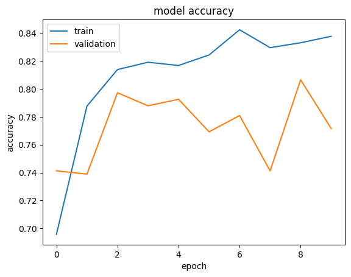

```python
history = run_binary_mlp(X_train_reshaped, y_train[:,0], X_test_reshaped, y_test[:,0],30,10)
plt.plot(history.history['accuracy'])
plt.plot(history.history['val_accuracy'])
plt.title('model accuracy')
plt.ylabel('accuracy')
plt.xlabel('epoch')
plt.legend(['train', 'validation'], loc='upper left')
plt.show()
```

## Exercise 5

In the following cell, execute at least 5 more experiments that experiment with the number of hidden neurons and number of epochs. **I would recommend only changing one hyperparameter at a time to be able to track the effect that each specific change is making**. Complete the table in the lab report that shows the configuration hyperparameters, total model parameters, test accuracy, and training accuracy. Describe why you think the highest accuracy configuration outperformed your other experiments.

[output not shown]

```
Model: "sequential_52"
_________________________________________________________________
 Layer (type)                Output Shape              Param #
=================================================================
 flatten_52 (Flatten)        (None, 50176)             0

 dense_104 (Dense)           (None, 64)                3211328

 dense_105 (Dense)           (None, 1)                 65

=================================================================
Total params: 3211393 (12.25 MB)
Trainable params: 3211393 (12.25 MB)
Non-trainable params: 0 (0.00 Byte)
_________________________________________________________________
Accuracy on train set: 83.94%
Accuracy on test set: 79.95%
[[157  26]
 [ 60 186]]
```

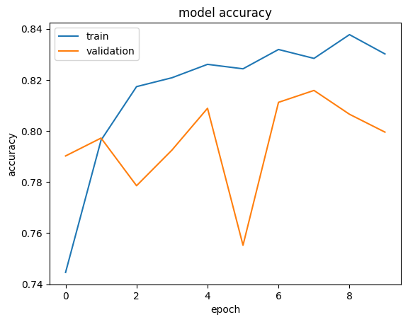

```python
history = run_binary_mlp(X_train_reshaped, y_train[:,0], X_test_reshaped, y_test[:,0],64,10)
plt.plot(history.history['accuracy'])
plt.plot(history.history['val_accuracy'])
plt.title('model accuracy')
plt.ylabel('accuracy')
plt.xlabel('epoch')
plt.legend(['train', 'validation'], loc='upper left')
plt.show()
```

## Exercise 6

In the following cell, modify the model itself by adding one additional dense layer and one Dropout layer (an example of how to add the dropout layer is shown in the model used for Exercise 8). Re-use your hyperparameters from your highest accuracy run in the previous exercise and capture the results in the lab report. Answer the questions in the lab report.

[output not shown]

```
Model: "sequential_54"
_________________________________________________________________
 Layer (type)                Output Shape              Param #
=================================================================
 flatten_54 (Flatten)        (None, 50176)             0

 dropout_1 (Dropout)         (None, 50176)             0

 dense_109 (Dense)           (None, 16)                802832

 dense_110 (Dense)           (None, 16)                272

 dense_111 (Dense)           (None, 1)                 17

=================================================================
Total params: 803121 (3.06 MB)
Trainable params: 803121 (3.06 MB)
Non-trainable params: 0 (0.00 Byte)
_________________________________________________________________
Accuracy on train set: 82.72%
Accuracy on test set: 78.32%
[[164  19]
 [ 74 172]]
```

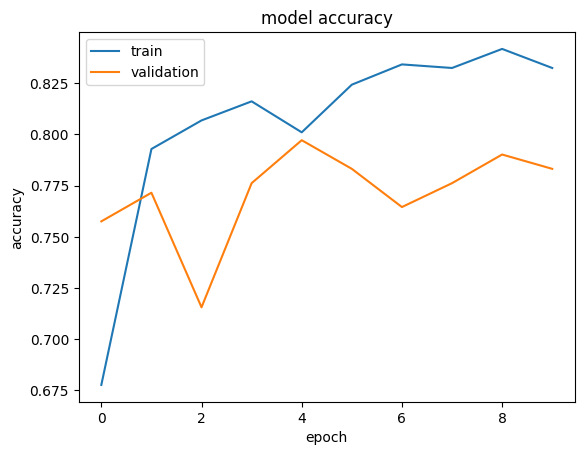

```python
def run_binary_mlp_two(X_train, y_train, X_test, y_test, hidden=16, epochs=100):
    model = Sequential()
    model.add(Flatten())
    model.add(Dropout(0.2))
    model.add(Dense(16))
    model.add(Dense(hidden, activation='relu'))
    model.add(Dense(1, activation='sigmoid'))
    model.compile(loss="binary_crossentropy",
              optimizer='SGD',
              metrics=['accuracy'])
    history = model.fit(x=X_train,y=y_train,
                        validation_data = (X_test, y_test),
                        batch_size=16,epochs=epochs,
                        verbose=1)
    model.summary()
    predicted_probabilities = model.predict(X_train)
    predicted_probabilities = np.rint(predicted_probabilities)
    acc = 100. * accuracy_score(y_train, predicted_probabilities)
    print("Accuracy on train set: {:.2f}%".format(acc))
    predicted_probabilities = model.predict(X_test)
    predicted_probabilities = np.rint(predicted_probabilities)
    acc = 100. * accuracy_score(y_test, predicted_probabilities)
    print("Accuracy on test set: {:.2f}%".format(acc))
    print(confusion_matrix(y_test, predicted_probabilities))
    return history

history = run_binary_mlp_two(X_train_reshaped, y_train[:,0], X_test_reshaped, y_test[:,0],16,10)
plt.plot(history.history['accuracy'])
plt.plot(history.history['val_accuracy'])
plt.title('model accuracy')
plt.ylabel('accuracy')
plt.xlabel('epoch')
plt.legend(['train', 'validation'], loc='upper left')
plt.show()
```

## Exercise 7

In the following cell, experiment with using at least 3 different activation functions. Keep other hyperparameters constant for these experiments and just change the activation functions. Record your results in the lab report.

**Do not change the activation function for the output layer (leave it 'sigmoid').** Other layers may be changed.

Information on different activation functions can be found here: https://mouaadblhn.medium.com/a-deep-dive-into-activation-functions-a-comprehensive-guide-for-neural-network-beginners-9ec7d03998f0 and examples for how to call them can be found here: https://www.geeksforgeeks.org/deep-learning/activation-function-in-tensorflow/

[output not shown]

```
Model: "sequential_57"
_________________________________________________________________
 Layer (type)                Output Shape              Param #
=================================================================
 flatten_57 (Flatten)        (None, 50176)             0

 dropout_4 (Dropout)         (None, 50176)             0

 dense_118 (Dense)           (None, 1)                 50177

 dense_119 (Dense)           (None, 16)                32

 dense_120 (Dense)           (None, 1)                 17

=================================================================
Total params: 50226 (196.20 KB)
Trainable params: 50226 (196.20 KB)
Non-trainable params: 0 (0.00 Byte)
_________________________________________________________________
Accuracy on train set: 84.76%
Accuracy on test set: 81.59%
[[129  54]
 [ 25 221]]
```

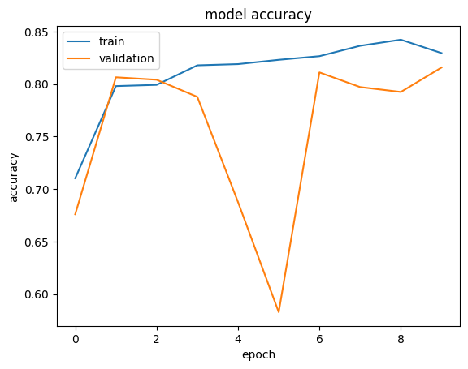

```python
def run_binary_mlp_three(X_train, y_train, X_test, y_test, hidden=16, epochs=100):
    model = Sequential()
    model.add(Flatten())
    model.add(Dropout(0.2))
    model.add(Dense(1, activation='swish'))
    model.add(Dense(hidden, activation='relu'))
    model.add(Dense(1, activation='sigmoid'))
    model.compile(loss="binary_crossentropy",
              optimizer='SGD',
              metrics=['accuracy'])
    history = model.fit(x=X_train,y=y_train,
                        validation_data = (X_test, y_test),
                        batch_size=16,epochs=epochs,
                        verbose=1)
    model.summary()
    predicted_probabilities = model.predict(X_train)
    predicted_probabilities = np.rint(predicted_probabilities)
    acc = 100. * accuracy_score(y_train, predicted_probabilities)
    print("Accuracy on train set: {:.2f}%".format(acc))
    predicted_probabilities = model.predict(X_test)
    predicted_probabilities = np.rint(predicted_probabilities)
    acc = 100. * accuracy_score(y_test, predicted_probabilities)
    print("Accuracy on test set: {:.2f}%".format(acc))
    print(confusion_matrix(y_test, predicted_probabilities))
    return history

history = run_binary_mlp_three(X_train_reshaped, y_train[:,0], X_test_reshaped, y_test[:,0],16,10)
plt.plot(history.history['accuracy'])
plt.plot(history.history['val_accuracy'])
plt.title('model accuracy')
plt.ylabel('accuracy')
plt.xlabel('epoch')
plt.legend(['train', 'validation'], loc='upper left')
plt.show()
```

## CNNs

One of the limitations of dense networks is that they don't inherently take advange of spatially-associated information. Using convolutional layers can enable the model to be able to learn more complicated features more efficiently since not all the layers are fully connected.

We start by creating a new generator for our CNN data to isolate it from previous experiments.

```python
# For part 8, you should adjust these ImageDataGenerator parameters to test different data augmentations
datagen_cnn = ImageDataGenerator(
            validation_split=0.2,
            rescale=1./255, # to bring the image range from 0..255 to 0..1
            rotation_range=0.01,  # randomly rotate images in the range (degrees, 0 to 180)
            zoom_range = 0.01, # randomly zoom image
            width_shift_range=0.01,  # randomly shift images horizontally (fraction of total width)
            height_shift_range=0.01,  # randomly shift images vertically (fraction of total height)
            horizontal_flip=False,  # randomly flip images
            vertical_flip=False) # randomly flip images



# Do not modify the flow_from_directory parameters unless you are making significant model changes that necessitate it
train_it_cnn = datagen_cnn.flow_from_directory( '/data/cs2300/pistachio/',
                                           target_size=(224,224),
                                           color_mode='grayscale',
                                           batch_size=32,
                                           class_mode="binary",
                                           shuffle=True,
                                           subset='training')

#Note that we are using the original "datagen" generator here
#Do not do data augmentation on the validation data set
valid_it_cnn = datagen.flow_from_directory( '/data/cs2300/pistachio/',
                                           target_size=(224,224),
                                           color_mode='grayscale',
                                           shuffle=True,
                                           batch_size=1,
                                           class_mode="binary",
                                           subset='validation')
```

```
Found 1719 images belonging to 2 classes.
Found 429 images belonging to 2 classes.
```

Next we create a function to define and run our CNN model.

```python
def run_binary_cnn(train_it, valid_it, cnn_epochs=10, deepness=1):
    '''This function takes a training and validation generator, builds and trains a model
    number of epochs is passed in as well as the deepness.
    deepness changes the structure of the model by adding layers for larger numbers
    '''
    cnn_model = Sequential()
    cnn_model.add(Conv2D(32, kernel_size=(3, 3),
                     activation='relu',
                     input_shape=(224,224,1)))
    cnn_model.add(MaxPooling2D(pool_size=(2, 2)))
    cnn_model.add(Conv2D(64, (3, 3), activation='relu'))
    cnn_model.add(MaxPooling2D(pool_size=(2, 2)))
    if(deepness > 1):
        cnn_model.add(Conv2D(128, (3, 3), activation='relu'))
        cnn_model.add(MaxPooling2D(pool_size=(2, 2)))
    if(deepness > 2):
        cnn_model.add(Conv2D(256, (3, 3), activation='relu'))
        cnn_model.add(MaxPooling2D(pool_size=(2, 2)))
    cnn_model.add(Flatten())
    if(deepness > 2):
        cnn_model.add(Dense(512, activation='relu'))
        cnn_model.add(Dropout(0.2))
    if(deepness > 1):
        cnn_model.add(Dense(256, activation='relu'))
    cnn_model.add(Dense(128, activation='relu'))
    cnn_model.add(Dense(1, activation='sigmoid'))

    cnn_model.compile(loss="binary_crossentropy",
                  optimizer='adam',
                  metrics=['accuracy'])
    history_cnn = cnn_model.fit(train_it_cnn,
                  validation_data=valid_it_cnn,
                  steps_per_epoch=train_it_cnn.samples/train_it_cnn.batch_size,
                  validation_steps=valid_it_cnn.samples/valid_it_cnn.batch_size,
                  epochs=cnn_epochs)
    return history_cnn
```

Let's run the model and see how it does...